# PseudoDojo notebook for H_r

```python
from __future__ import print_function, division, unicode_literals
#import seaborn
%matplotlib inline
```

```python
from IPython.display import HTML
HTML('''
<style>
body {
background-image: url('http://www.pseudo-dojo.org/img/pw_maze_white.png');
}
</style>
<script>
code_show=true;
function code_toggle() {
 if (code_show) {
    $('div.input').hide();
 } else {
    $('div.input').show();
 }
 code_show = !code_show;
}
$(document).ready(code_toggle);
</script>
The raw code for this IPython notebook is by default hidden for easier reading.
To toggle on/off the raw code, click <a href="javascript:code_toggle()">here</a>.''')
```

The raw code for this IPython notebook is by default hidden for easier reading. To toggle on/off the raw code, click here.

```python
from pseudo_dojo.core.pseudos import dojopseudo_from_file
pseudo = dojopseudo_from_file('/Users/setten/software/conda_install/setten_stack/pseudo_dojo/pseudo_dojo/pseudos/ONCVPSP-PBE-FR-PDv0.4/H/testy/H_r.psp8')
report = pseudo.dojo_report
```

## ONCVPSP Input File

```python
input_file = pseudo.filepath.replace(".psp8", ".in")
%cat $input_file
```

```
# atsym z nc nv iexc psfile
H 1 0 1 4 both
# n l f
1 0 1.0
# lmax
1
# l rc ep ncon nbas qcut
0 1.0 0.0 4 7 8.5
1 0.7 0.05 4 7 11.0
# lloc lpopt rc5 dvloc0
4 5 0.7 0.0
# l nproj debl
0 2 1.0
1 1 1.0
# icmod fcfact rcfact
0 0.25 0.0
# epsh1 epsh2 depsh
-12.0 12.0 0.02
# rlmax drl
3.0 0.01
 0
```

```python
# Get data from the oncvpsp output file
from pseudo_dojo.ppcodes.oncvpsp import OncvOutputParser, PseudoGenDataPlotter
onc_parser = OncvOutputParser(pseudo.filepath.replace(".psp8", ".out"))

# Parse the file and build the plotter
onc_parser.scan()
plotter = onc_parser.make_plotter()
```

## AE and PS radial wavefunctions $\phi(r)$

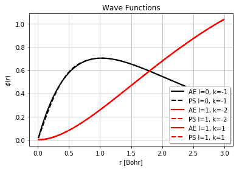

```python
fig = plotter.plot_radial_wfs()
```

## Arctan of the logarithmic derivatives

From the oncvpsp documentation: The plots show $\phi(E) = \arctan(R * d \psi(r)/dr |_R)$ for some $R$ greater than the core radius, where $\psi$ is the solution of the non-local radial equation regular at the origin (i.e., the outward-integrated solution). For a well-designed pseudopotential, $\phi(E)$ will closely track that of the all-electron potential over a wide range of energies from well-below to well-above the valence semi-core states of interest. The steps of $\pi$ indicate localized pseudo wave functions. Spurious steps of $\pi$ indicate "ghost" states, which are localized states than on investigation turn out to have more nodes than appropriate for their energies.

For $GW$ pseudos, no significant deviation should be present up to 8 Hartree.

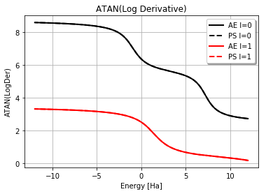

```python
fig = plotter.plot_atan_logders()
```

## Convergence in $G$-space estimated by ONCVPSP

These results are obtained in the atomic configuration and should give a reasonable estimate of the convergence behaviour wrt to `ecut` in crystalline systems.

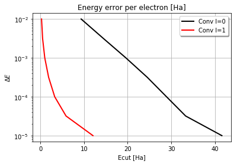

```python
fig = plotter.plot_ene_vs_ecut()
```

## Projectors

In general the second projector in any channel should have one node more that the first one. Pushing the energy of the second projector too high may cause an additional node. This will most likely introduce ghosts.

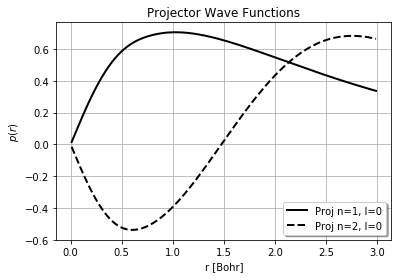

```python
fig = plotter.plot_projectors()
```

## Core-Valence-Model charge densities

Much better convergence properties can been achieved with `icmod 3`. In this case, `fcfact` mainly determines the height of the model core charge while `rcfact` mainly determines the width of the model core charge.

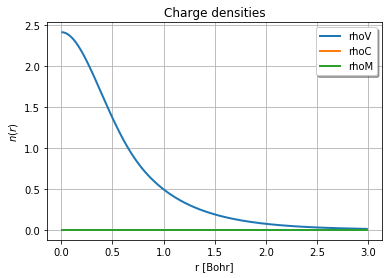

```python
fig = plotter.plot_densities()
```

## Local potential and $l$-dependent potentials

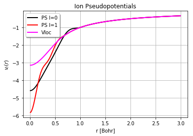

```python
fig = plotter.plot_potentials()
```

## Ghosts Test

```python
fig = report.plot_ebands(with_soc=False)
```

[output not shown]

```
dojo report does not contain trial: ghosts
```

## Convergence of the total energy wrt ecut

```python
fig = report.plot_etotal_vs_ecut()
```

[output not shown]

```
dojo report does not contain trial: deltafactor
```

```python
fig = report.plot_etotal_vs_ecut(inv_ecut=True)
```

[output not shown]

```
dojo report does not contain trial: deltafactor
```

## Convergence of the Delta-Gauge results

A comparison using the Delta-gauge between many codes and many pseudo tables can be found at the [center for molecular modeling](http://molmod.ugent.be/deltacodesdft) and in [Science 351, 1394-1395](http://science.sciencemag.org/content/351/6280/aad3000.full?ijkey=teUZMpwU49vhY&keytype=ref&siteid=sci)

```python
fig = report.plot_deltafactor_convergence(xc=pseudo.xc, what=("dfact_meV", "dfactprime_meV"))
```

[output not shown]

```
dojo report does not contain trial: deltafactor
```

## Convergence of $\Delta v_0$, $\Delta b_0$, and $\Delta b_1$ (deltafactor tests)

```python
# Absolute difference with respect to Wien2k results.
fig = report.plot_deltafactor_convergence(xc=pseudo.xc, what=("-dfact_meV", "-dfactprime_meV"))
```

[output not shown]

```
dojo report does not contain trial: deltafactor
```

## Delta-gauge EOS for the different cutoff energies

```python
fig = report.plot_deltafactor_eos()
```

[output not shown]

```
dojo report does not contain trial: deltafactor
```

## Convergence of the GBRV lattice parameters

```python
fig = report.plot_gbrv_convergence()
```

[output not shown]

```
dojo report does not contain trial: gbrv_fcc
```

## Convergence of the phonon frequencies at $\Gamma$

```python
fig = report.plot_phonon_convergence()
```

[output not shown]

```
dojo report does not contain trial: phgamma
```

## GBRV EOS for the FCC structure

```python
fig = report.plot_gbrv_eos(struct_type="fcc")
```

[output not shown]

```
dojo report does not contain trial: gbrv_fcc
```

## GBRV EOS for the BCC structure

```python
fig = report.plot_gbrv_eos(struct_type="bcc")
```

[output not shown]

```
dojo report does not contain trial: gbrv_bcc
```

## Convergence of rocksalt lattice parameter.

```python
fig = report.plot_raren_convergence(pseudo.xc)
```

[output not shown]

```
dojo report does not contain trial: raren_relax
```

```python
fig = report.plot_raren_convergence(pseudo.xc, plot_diffs=True)
```

[output not shown]

```
dojo report does not contain trial: raren_relax
```